# 08-01 Introduction to ggplot

Emily Beam

What do we see here. Things look okay, but usually we don’t think of days of the week and months as numbers. We want to name them!

```r
head(births_combined)
```

```
## # A tibble: 6 x 5
##    year month date_of_month day_of_week births
##   <dbl> <dbl>         <dbl>       <dbl>  <dbl>
## 1  1994     1             1           6   8096
## 2  1994     1             2           7   7772
## 3  1994     1             3           1  10142
## 4  1994     1             4           2  11248
## 5  1994     1             5           3  11053
## 6  1994     1             6           4  11406
```

1. Make list of names for months and days of the week
2. Make two new variables, `month` and `day_of_week` that are ordered factors. “Factors” just means they are categorical variable, and ordered means that one comes before another (we wouldn’t want them in alphabetical order, for example)
3. Make a variable called weekend that equals 1 if it is Saturday/Sunday, and 0 otherwise.

```r
# The c() function lets us make a list of values
month_names <- c("January", "February", "March", "April", "May", "June", "July",
                 "August", "September", "October", "November", "December")

day_names <- c("Monday", "Tuesday", "Wednesday",
               "Thursday", "Friday", "Saturday", "Sunday")


births <- births_combined %>%
  # Make month an ordered factor, using the month_name list as labels
  mutate(month = factor(month, labels = month_names, ordered = TRUE)) %>%
  mutate(day_of_week = factor(day_of_week, labels = day_names, ordered = TRUE),
         date_of_month_categorical = factor(date_of_month)) %>%
  # Add a column indicating if the day is on a weekend
  mutate(weekend = ifelse(day_of_week %in% c("Saturday", "Sunday"), TRUE, FALSE))

head(births)
```

```
## # A tibble: 6 x 7
##    year month   date_of_month day_of_week births date_of_month_categori… weekend
##   <dbl> <ord>           <dbl> <ord>        <dbl> <fct>                   <lgl>
## 1  1994 January             1 Saturday      8096 1                       TRUE
## 2  1994 January             2 Sunday        7772 2                       TRUE
## 3  1994 January             3 Monday       10142 3                       FALSE
## 4  1994 January             4 Tuesday      11248 4                       FALSE
## 5  1994 January             5 Wednesday    11053 5                       FALSE
## 6  1994 January             6 Thursday     11406 6                       FALSE
```

If you look at the data now, you can see the columns are changed and have different types. year and date_of_month are still numbers, but month, and day_of_week are ordered factors (ord) and date_of_month_categorical is a regular factor (fct). Technically it’s also ordered, but because it’s already alphabetical (i.e. 2 naturally comes after 1), we don’t need to force it to be in the right order.

Our births data is now clean and ready to go!

See what happens when you delete and replace little bits of code:

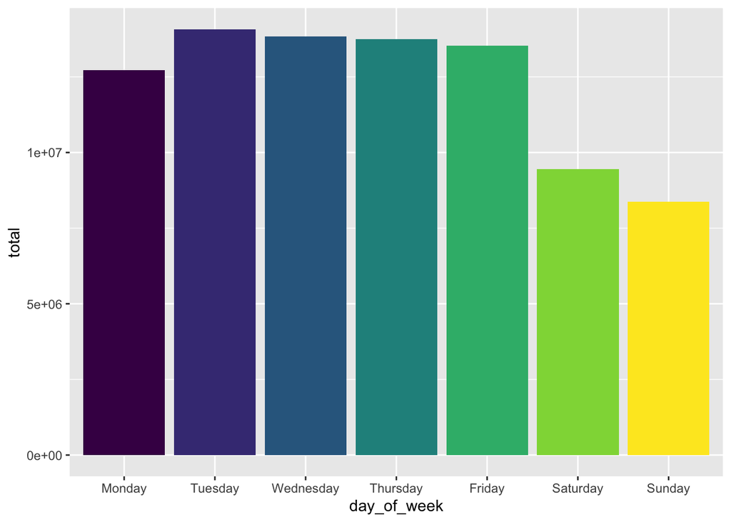

```r
total_births_weekday <- births %>%
  group_by(day_of_week) %>%
  summarize(total = sum(births))

ggplot(data = total_births_weekday,
       mapping = aes(x = day_of_week, y = total, fill = day_of_week)) +
  geom_col() +
  # Turn off the fill legend because it's redundant
  guides(fill = FALSE)
```

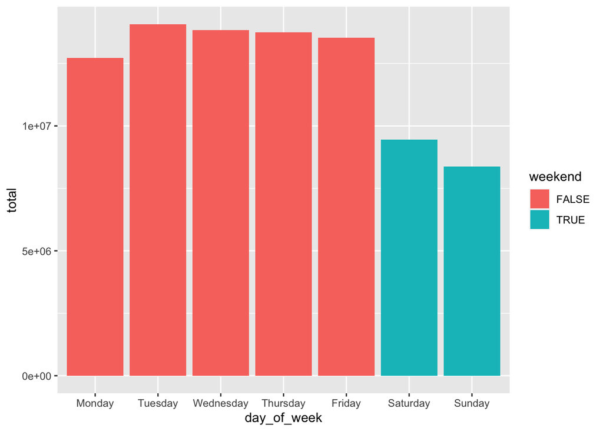

```r
total_births_weekday <- births %>%
  group_by(day_of_week) %>%
  summarize(total = sum(births)) %>%
  mutate(weekend = ifelse(day_of_week %in% c("Saturday", "Sunday"), TRUE, FALSE))

ggplot(data = total_births_weekday,
        mapping = aes(x = day_of_week, y = total, fill = weekend)) +
  geom_col()
```

This graph makes three modifications: - `scale_fill_manual()` - adds specific colors - `scale_y_continuous(labels = comma)` - gets away from scientific notation - `labs()` - add some labels

Currently they are commented out. Add them back in. Note that you need to connect them with a + in order to make it work, and the + has to be at the end of the line.

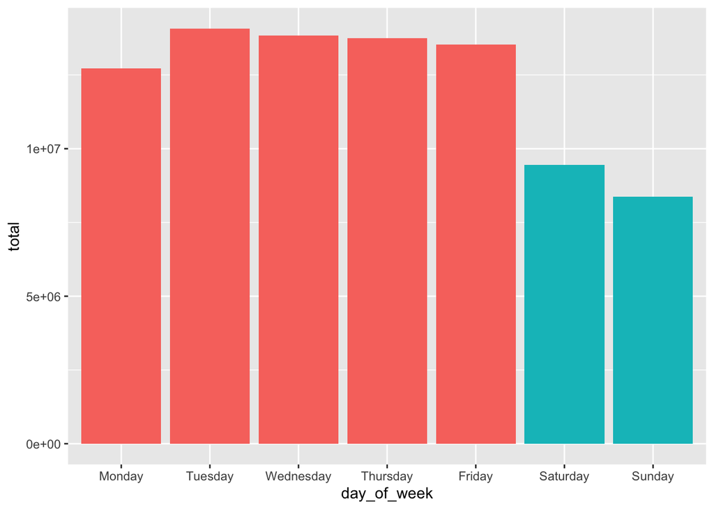

```r
ggplot(data = total_births_weekday,
       mapping = aes(x = day_of_week, y = total, fill = weekend)) +
  geom_col() +
  # Use grey and orange
  #scale_fill_manual(values = c("grey70", "#f2ad22")) +
  # Use commas instead of scientific notation
  #scale_y_continuous(labels = comma) +
  # Turn off the legend since the title shows what the orange is
  guides(fill = FALSE)
```

```r
  #labs(title = "Weekends are unpopular times for giving birth",
  #     x = NULL, y = "Total births")
```

Here, we’ve brought in a new geom - `geom_pointrange`. You can make this look even better if you add in options to increase the size of the dots and width of the lines. Add options `fatten = 5, size = 1.5` after the comma: `geom_pointrange(aes(ymin = 0,ymax = total),PUT HERE)`. Feel free to play w/ the exact sizes.

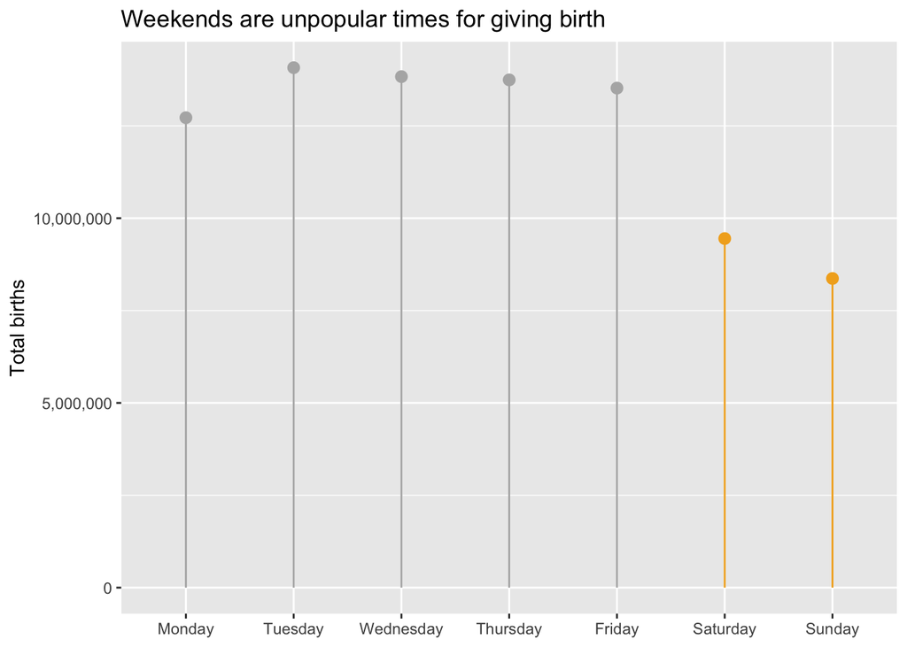

```r
ggplot(data = total_births_weekday,
       mapping = aes(x = day_of_week, y = total, color = weekend)) +
  geom_pointrange(aes(ymin = 0, ymax = total), )+
                  # Make the lines a little thicker and the dots a little bigger
                  # fatten = 5, size = 1.5) +
  # Use grey and orange
  scale_color_manual(values = c("grey70", "#f2ad22")) +
  # Use commas instead of scientific notation
  scale_y_continuous(labels = comma) +
  # Turn off the legend since the title shows what the orange is
  guides(color = FALSE) +
  labs(title = "Weekends are unpopular times for giving birth",
       x = NULL, y = "Total births")
```

Now, let’s make a cool strip plot. See what the `jitter` is doing by removing `position=position_jitter(height = 0)`.

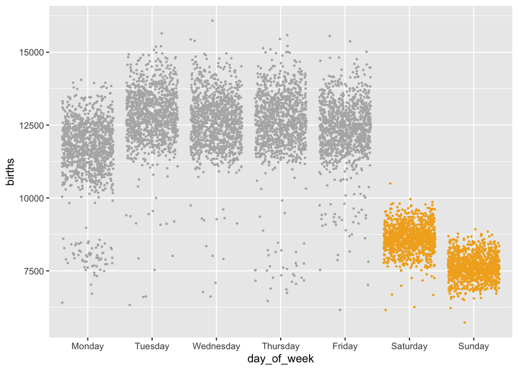

```r
ggplot(data = births,
       mapping = aes(x = day_of_week, y = births, color = weekend)) +
  scale_color_manual(values = c("grey70", "#f2ad22")) +
  geom_point(size = 0.5, position = position_jitter(height = 0)) +
  guides(color = FALSE)
```

To make a pretty version of a violin plot (“bee swarm”), you will need to install the package `ggbswarm` (see in code). Once you install it, comment it back out.

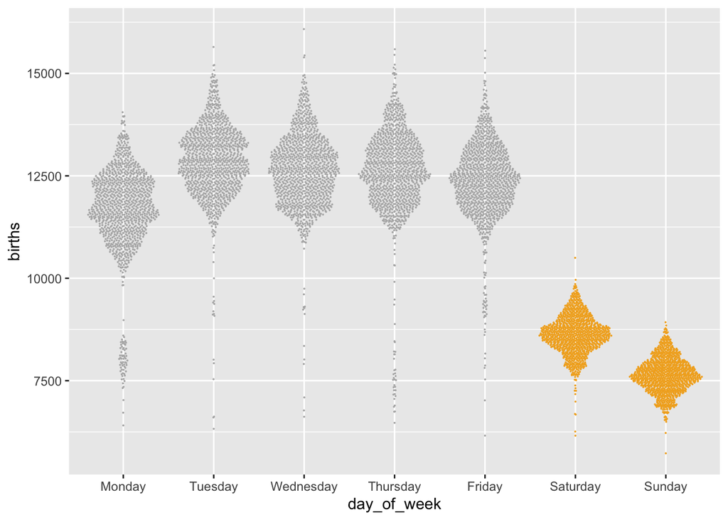

```r
#install.packages("ggbeeswarm")
library(ggbeeswarm)

ggplot(data = births,
       mapping = aes(x = day_of_week, y = births, color = weekend)) +
  scale_color_manual(values = c("grey70", "#f2ad22")) +
  # Make these points suuuper tiny
  geom_quasirandom(size = 0.0001) +
  guides(color = FALSE)
```

Now, let’s make a heat map!

Look closely at what we’re doing 1. Generating a data frame that summarizes average births per day over the entire period 2. Plotting average births as the fill using `geom_tile`.

```r
avg_births_month_day <- births %>%
  group_by(month, date_of_month_categorical) %>%
  summarize(avg_births = mean(births))
```

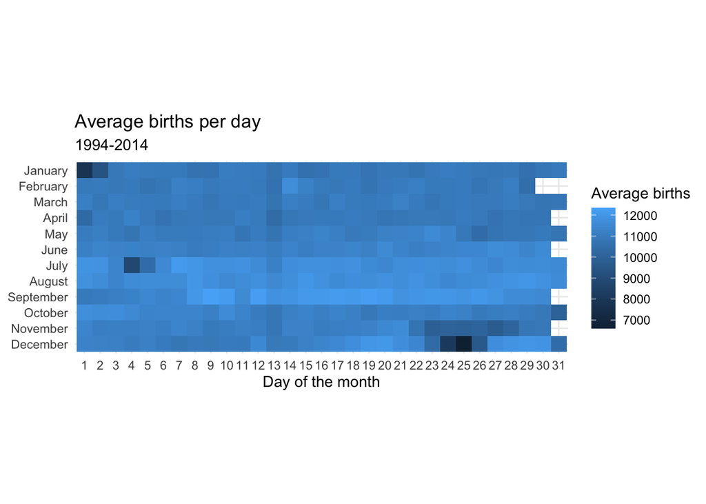

```r
ggplot(data = avg_births_month_day,
       # By default, the y-axis will have December at the top, so use fct_rev() to reverse it
       mapping = aes(x = date_of_month_categorical, y = fct_rev(month), fill = avg_births)) +
  geom_tile() +
  # Add nice labels
  labs(x = "Day of the month", y = NULL,
       title = "Average births per day",
       subtitle = "1994-2014",
       fill = "Average births") +
  # Force all the tiles to have equal widths and heights
  coord_equal() +
  # Use a cleaner theme
  theme_minimal()
```

## Your turn!

### Set-up

1. Head to your groups
2. Make sure you can run all the code. Remember you can select “Run All” to run from top to bottom. You may need to install a package or two.

### Now, let’s play a little bit and get more comfortable

1. Work through the questions above.
2. See the `labs` command we use in the heatmap? Add a set of labels to unlabelled graphs that include the following
- Title
- Subtitle
- Nice y-axis title
- Nice x-axis title

*Nice that we don’t have to recreate the entire graph again, right? We can just edit within what we already have*

2. Let’s suppose we want to see how much variation there is in December births. Make a histogram that shows the distribution of births in December. I’ve given some hints in the comments

```r
# You'll want to use this form
## births %>% then filter(STUFF) %>% then start your ggplot commands. You don't need to do any additional data cleaning

## For your ggplot, you'll want to use geom_histogram()
```

3. What happens if we add a “fill” to our histogram? Create a new graph that includes `fill=day_of_week` in your aes mapping. What is being plotted now?
4. *(If you have time)* What if we want to make a bar chart of total number of births per year? You can do this in a way similar to the `barplot` chunk above, but you’ll want to group by year.

```r
births_total = births %>%
  group_by(year) %>%
  summarize(total = sum(births))

# Now, add a bar chart
```

5. Once you’ve got that running, can you make it into a line chart? Just swap out `geom_col` with `geom_line`! Wow, that is a lot clearer!